# Identify Game Clusters and Nearest Neighbors

Phil Henrickson

2021-12-20

# What is this Analysis?

This notebook is for using unsupervised learning methods based on selected features for board games in order to understand the main points of variation and clusters in data about games on boardgamegeek.

The data we are using from boardgamegeek was last refreshed on **2021-12-20**. As of this date, there are **21696** on boardgamegeek with at least 30 user ratings. We are running this analysis on **2021-12-20.**

# Assemble and Prepare Data

We’ll assemble our training dataset to start, meaning we will start with games published before 2020 and then pull in the other datasets to create features at the game level.

We’ll now create a recipe prepping and normalizing our data for clustering/PCA. `

```r
recipe_prep<- recipe(~ .,
                    x = games_train) %>%
        update_role(all_numeric(),
              new_role = "predictor") %>%
        update_role(timestamp,
              yearpublished,
                usersrated,
                game_id,
                name,
                average,
                baverage,
                new_role = "id") %>%
        step_filter(!is.na(yearpublished)) %>%
        step_filter(cat_collectible_components !=1 &
              cat_expansion_for_basegame != 1) %>% # remove specific categories that count expansions
#  step_filter(yearpublished > 1900) %>%
  # step_mutate(published_prior_1900 = case_when(yearpublished<1900 ~ 1,
  #                                              TRUE ~ 0)) %>%
  # step_mutate(yearpublished = case_when(yearpublished <= 1900 ~ 1900,
  #                                              TRUE ~ as.numeric(yearpublished))) %>% # truncate yearpublished
 # step_mutate(years_since_published = as.numeric(year(Sys.Date()))-yearpublished) %>%
  step_impute_median(avgweight,
                            minplayers,
                            maxplayers,
                            playingtime,
                            minage) %>% # medianimpute numeric predictors
  step_mutate(minplayers = case_when(minplayers < 1 ~ 1,
                                             minplayers > 10 ~ 10, # truncate
                                             TRUE ~ minplayers),
              maxplayers = case_when(maxplayers < 1 ~ minplayers,
                                             maxplayers > 20 ~ 20,
                                             TRUE ~ maxplayers)) %>% # truncate player range
  step_mutate(time_per_player = playingtime/ maxplayers) %>% # make time per player variable
  step_mutate_at(starts_with("cat_"),
                   fn = ~ replace_na(., 0)) %>%
  step_mutate_at(starts_with("mech_"),
                   fn = ~ replace_na(., 0)) %>%
  step_mutate_at(starts_with("des_"),
                   fn = ~ replace_na(., 0)) %>%
  step_mutate_at(starts_with("art_"),
                   fn = ~ replace_na(., 0)) %>%
  step_rm(starts_with("art_"),
          starts_with("des_"),
          starts_with("pub_")) %>%
  step_mutate(number_mechanics = rowSums(across(starts_with("mech_"))),
              number_categories = rowSums(across(starts_with("cat_")))) %>%
  step_log(playingtime,
           time_per_player,
           offset = 1) %>%
  step_zv(all_predictors()) %>%
        step_corr(all_predictors(),
                    threshold = 0.99) %>%
  step_nzv(all_predictors(),
           freq_cut = 150/1)

# normalize
recipe_norm_prep<-recipe_prep %>%
#  step_poly(number_mechanics, degree = 2) %>%
  step_normalize(all_predictors())


# summary of recipe
summary(recipe_prep)
```

```
## # A tibble: 740 × 4
##    variable      type    role      source
##    <chr>         <chr>   <chr>     <chr>
##  1 timestamp     date    id        original
##  2 game_id       numeric id        original
##  3 name          nominal id        original
##  4 average       numeric id        original
##  5 baverage      numeric id        original
##  6 usersrated    numeric id        original
##  7 yearpublished numeric id        original
##  8 avgweight     numeric predictor original
##  9 minage        numeric predictor original
## 10 minplayers    numeric predictor original
## # … with 730 more rows
```

We’ll then bake and get our dataset at the nested level. We will use two different sets of features when examining the variation in games.

```r
# bake
baked_train = recipe_prep %>%
        prep(games_train, strings_as_factor = F) %>%
        bake(new_data = NULL)

# create two datasets
nested_train_data<- baked_train %>%
  mutate(dataset = "fundamentals, mechanics, and categories") %>%
  nest(-dataset) %>%
  bind_rows(., baked_train %>%
              mutate(dataset = "fundamentals and mechanics") %>%
              select(-starts_with("cat_"),
                     -number_categories) %>%
              nest(-dataset))
```

Next is just setting up a bunch of functions for fitting PCA and clustering to these nested datasets, doing so inside of recipes.

```r
# function for standard recipe
pca_recipe= function(df) {

  recipe = recipe(~.,
                  data = df) %>%
   update_role(timestamp,
              yearpublished,
                usersrated,
                game_id,
                name,
                average,
                baverage,
                new_role = "id") %>%
    step_normalize(all_numeric_predictors()) %>%
    step_pca(all_numeric_predictors(), id = "pca",
             num_comp = 500) %>%
    prep(strings_as_factor=F)

}

norm_recipe= function(df) {

  recipe = recipe(~.,
                  data = df) %>%
   update_role(timestamp,
              yearpublished,
                usersrated,
                game_id,
                name,
                average,
                baverage,
                new_role = "id") %>%
    step_normalize(all_numeric_predictors()) %>%
    prep(strings_as_factor=F)

}
```

# PCA

We’ll now fit the pca on the training set, then extract various quantities from it.

How much of the variation is explained by each component?

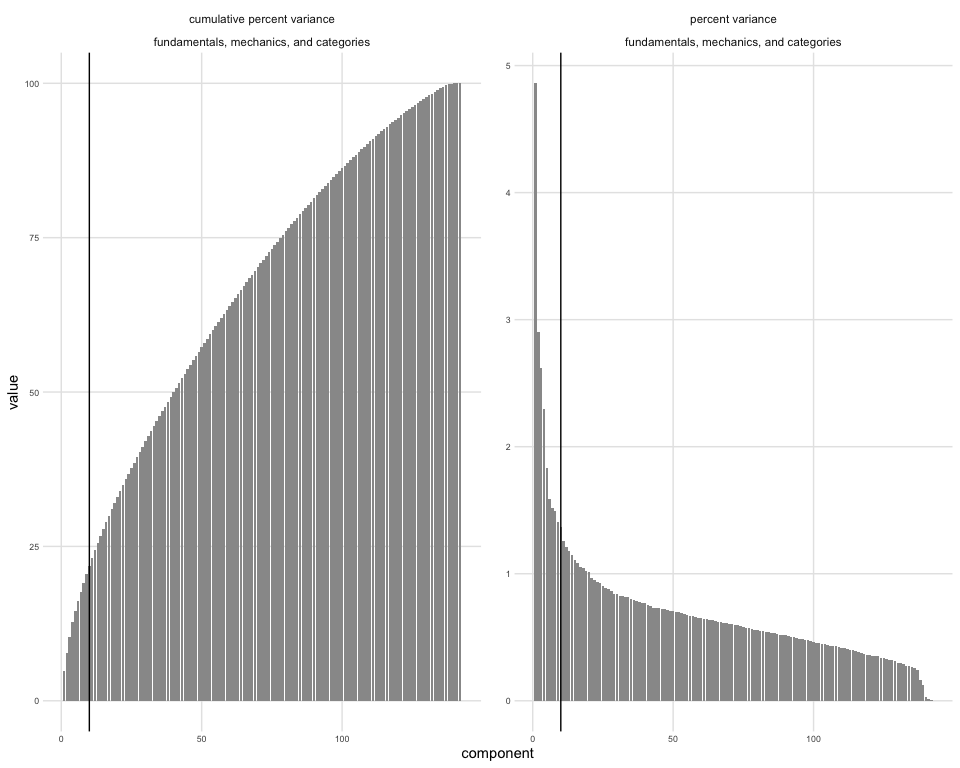

For instance, we can plot the top variable loadings for the first 10 components.

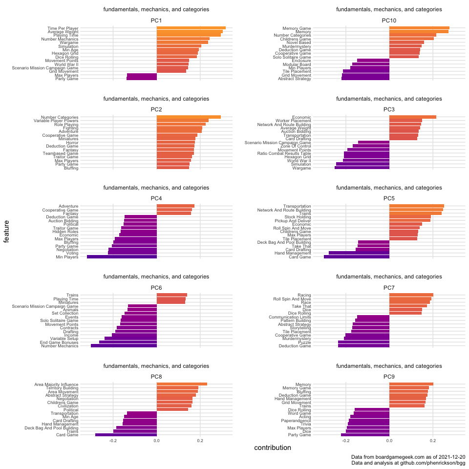

We can also plot each game by the first two components.

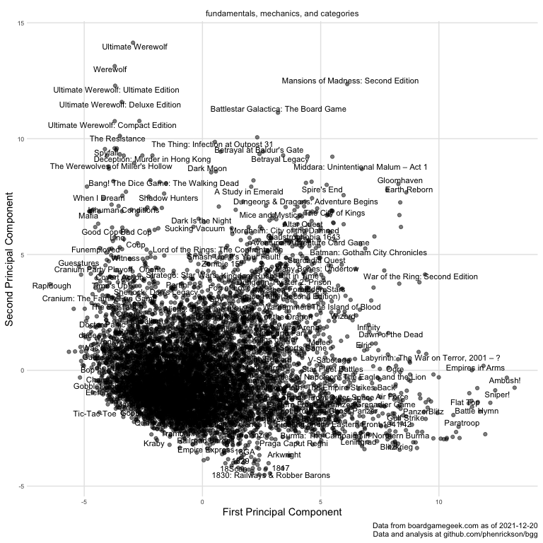

# K Means

Let’s now use K means to identify the clusters that are present in the data.

How many clusters should there be? We’ll use the elbow method to look for the minimal set of clusters that explains the variation.

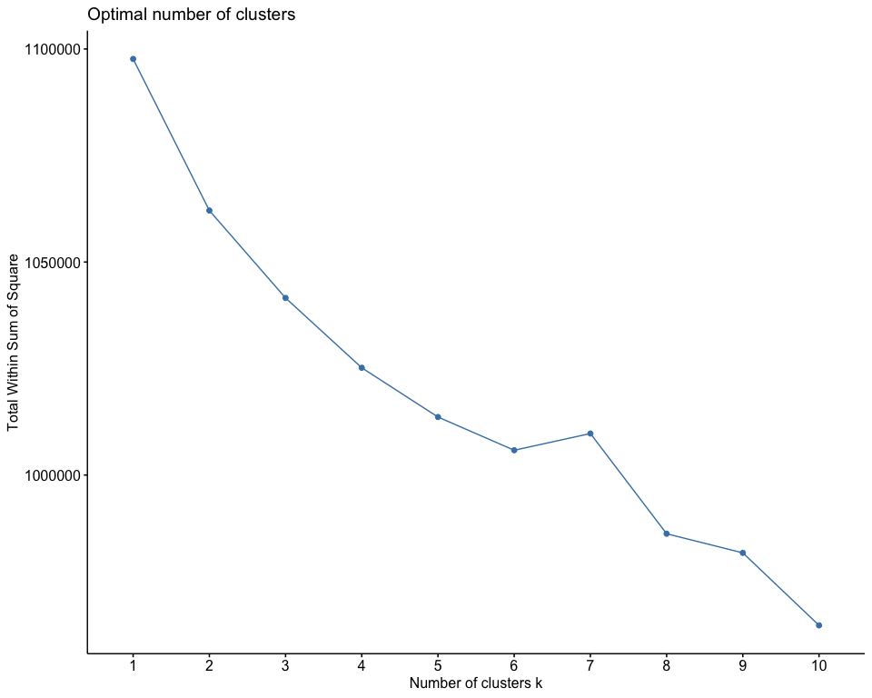

Hmm. Let’s go with 6 clusters.

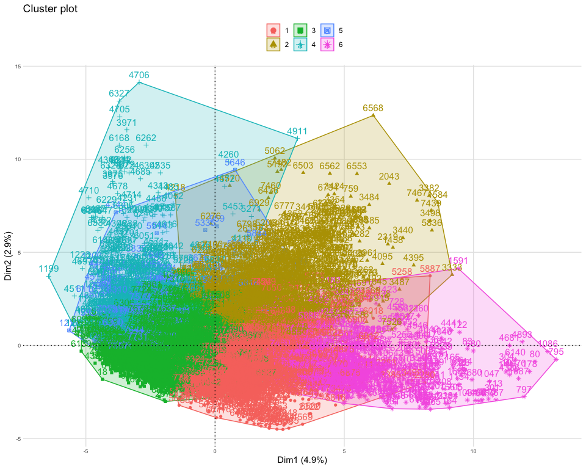

We can take a look at the games in each cluster.

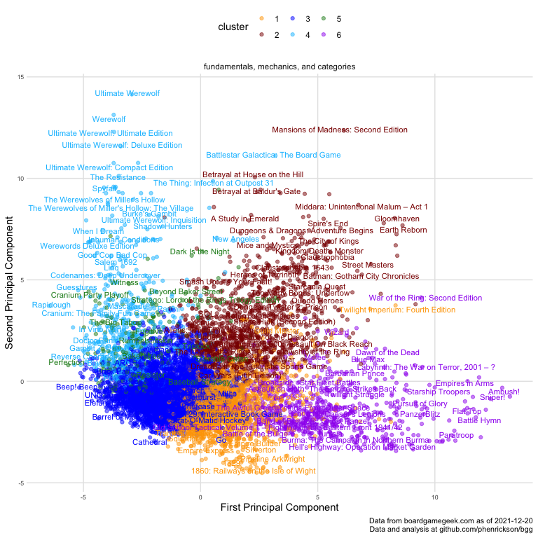

I’ll sample from within each cluster to get a sense of what each cluster contains.

Sample of 100 Games for Each Cluster

| Cluster_1 | Cluster_2 | Cluster_3 | Cluster_4 | Cluster_5 | Cluster_6 |
| --- | --- | --- | --- | --- | --- |
| Tiny Epic Dinosaurs | Dragon Strike | Adventure Time Card Wars: Finn vs. Jake | Facts in Five | The Game of Authors | Roads to Leningrad |
| Mercante | Defenders of the Realm | Don Pepe | Thingamajig | In a Grove | Levée en Masse: The Wars of the French Revolution |
| Skyline 3000 | Lord of the Rings: The Search | Electronic Battleship | Password | Dracula's Feast | Fortress America |
| Junk Orbit | The Oregon Trail Card Game | Firefly Fluxx | Wits & Wagers Family | Complots | Warhammer 40,000: Kill Team |
| Samhain | Pandemonium | Eternal: Chronicles of the Throne | Bring Your Own Book | Survive: Escape from Atlantis! | Thunder at Cassino |
| Stockpile | Quest: A Time of Heroes | Holiday Fluxx | Trivial Pursuit: Genus IV | Sobek | The Hunt for Red October |
| Hab & Gut | Sherlock Holmes Consulting Detective: Jack the Ripper & West End Adventures | Triovision | The Red Dragon Inn | Stop Thief! | Siege |
| City Tycoon | Unmatched Game System | Secret Labyrinth | Trivial Pursuit: 90's Time Capsule Edition | Perfection | Mission Command Land |
| Arkadia | Aeon's End: War Eternal | Pirateer | GoodCritters | Magic Hill | Advanced Squad Leader: Starter Kit #3 |
| Chinatown | Legend of Zagor | Spoils of War | [kosmopoli:t] | The Da Vinci Code Board Game: The Quest for the Truth | Imperial Struggle |
| The Ancient World | Golem Arcana | Shadow Throne | Taboo | Poseidon's Kingdom | Bobby Lee: The Civil War in Virginia 1861-1865 |
| Monopoly Cheaters Edition | Monolith Arena | Knapp Daneben! | Shadow Hunters | Déjà Vu | The Lamps Are Going Out |
| Atheneum: Mystic Library | Pixel Tactics 2 | Thermopyles | BANG! | Inner Circle | Wilderness War |
| The Prodigals Club | Salvation Road | Masterpiece | Mysterium | Kitty Bitty | Phantom Leader |
| Exodus: Proxima Centauri | Archmage | Flash Duel: Second Edition | Scape Goat | Outfoxed! | Grant Takes Command |
| Kingsburg (Second Edition) | All Wound Up | Planes | Trivial Pursuit: Master Edition | Sleeping Queens | Kingmaker |
| Rococo | Rescue Polar Bears: Data & Temperature | Mega Man Pixel Tactics: Mega Man Blue | Who Wants to Be a Millionaire | Clue Suspect | A Most Dangerous Time: Japan in Chaos, 1570-1584 |
| Mini Rails | Solenia | Dungeon Mayhem: Monster Madness | Codenames | Los Mampfos | Hundred Days Battles |
| Greed Incorporated | My Little Scythe | Cardline: Dinosaurs | GROWL | Scopa | Air War: Modern Tactical Air Combat |
| Paladins of the West Kingdom | CloudAge | Madame Ching | Junta: Las Cartas | Eselsbrücke | Conquistador: The Age of Exploration |
| Mall World | WWE Superstar Showdown | Railroad Ink: Deep Blue Edition | In a Pickle | Raise Your Goblets | Axis & Allies: Battle of the Bulge |
| Irish Gauge | Buffy the Vampire Slayer: The Game | Quadropolis | Timeline: Events | Fugitive | The Korean War June 1950-May 1951 |
| Penny Press | The Dwarves | Dragonology: The Game | On a Scale of One to T-Rex | Gobblet | Grand Illusion: Mirage of Glory, 1914 |
| Macao | Magestorm | SUTAKKU | Crappy Birthday | Masque of the Red Death | No Peace Without Spain!: The War of the Spanish Succession 1702-1713 |
| Ulm | Dungeon Fighter | Kuhhandel Master | Avocado Smash! | Khan of Khans | PanzerBlitz |
| Atlantis Rising | Wizard School | Rancho | Trivial Pursuit: The 1980's | Buccaneer | Assault on Hoth: The Empire Strikes Back |
| Colonial: Europe's Empires Overseas | Cosmic Encounter Duel | Unlock!: Mystery Adventures – The Nautilus' Traps | Fictionaire | The 3 Commandments | Western Front Tank Leader |
| Forged in Steel | Vengeance | Dune | Robin Hood | Die Siedler von Catan: Junior | France '40 |
| Succession: Intrigue in the Royal Court | Arkham Noir: Case #1 – The Witch Cult Murders | Yamslam | Scene It? Movie Second Edition | Sherlock: 13 Hostages | Storm over Arnhem |
| Carcassonne: The Castle | Warmachine | Combo Color | Obama Llama | Dungeon Heroes | Blue Max |

[output cut: 70 more lines]

We’ll use the kmeans function to assign every game to clusters.

# Finding Nearest Neighbors

We’ll now use the distance matrix to identify the closest neighbors for all games. How should we use these to compute similarity between games? This amounts to finding the distance between games on the principal components. I’m calculating the Euclidean distance and the Manhattan distance for now the first ten principal components.

This gives us distance measures computed in slightly different ways, which will yield different comparables. Let’s compare them! We’ll sample a few games and see how the nearest neighbors based on these distance measures compare.

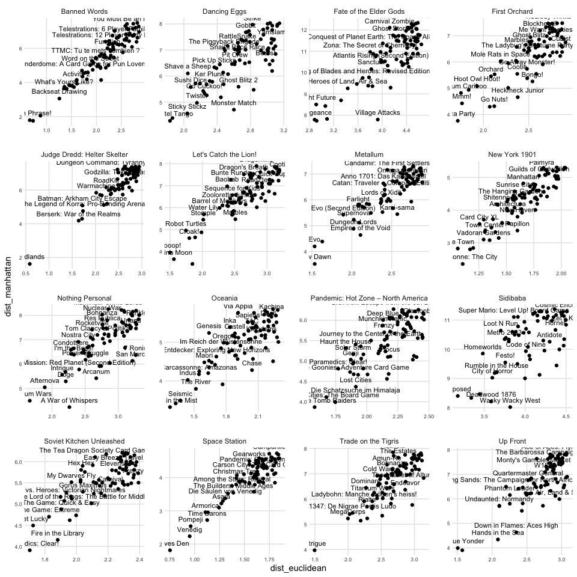

They’re generally pretty similar, but they do disagree at times. We can dig into this in greater detail later, but based on some initial tests I’ve diecided to go with Manhattan distance for now.

Regardless of method, we can compute each game’s neighbors by finding the games with the minimal distance.

# Placing New Games

We can now add in the games from our test set and place them here. Create our nested set.

Now find neighbors for new games.

We can then assign clusters and store the output of this for further analysis and use.

We’ll then output the models and neighbors for later use.